# STA4141/2104 Week 9: Building Predictive Models

This is part 1 of two parts this week: part 2 is a standard Beamer presentation on **validating** predictive models.

# Introduction

Up to this point, we have spent a lot of time (well, all of our time) talking about how to build predictive models from scratch.

Our discussion has focussed entirely on what to do, conceptually and practically, once we have our data structured in a matrix $X$, with observations in the rows and features in the columns. We haven’t talked about

- How to get the data into this format
- What to do with a model that we build, and how to decide which model is best for a given dataset

In this lecture, we will go through the basics of getting data ready for model-building, and then validating and comparing the models we do build.

This notebook contains two relatively simple cases of reading in and preprocessing data- however, I approached the task with a similar level of detail as one might be expected to use when dealing with massive datasets in industry (although I had to skip steps). The purpose of this document is to illustrate the types of challenges you will face when working with real, large datasets.

# Data Preparation

Broadly speaking, there are two classes of data that we might encounter in practice. Both kinds require preprocessing.

- **Structured** data exists in row-column format already, usually in a relational database that we would access through a Relational Database Management Software (RDMS) using SQL. The data may be stored in many tables across many different databases that need to be joined; but we still call it **structured** since the rows contain observations and the columns contain features.
- **Unstructured** data is any data that is not structured as above. Images, videos, text, sound, graphical data- most of the currently “hot” datatypes are **unstructured**

Preprocessing for these types of data are fundamentally different:

- For **structured** data, the features are directly interpretible (hopefully). They could be things like “credit card balance” or “age” or something else that we directly interpret as being relevant to the prediction problem at hand. Preprocessing these data involves screening redundant or non-varying features, detecting outliers, standardizing features to have the same scale, and so on
- For **unstructured** data, preprocessing involves actually creating the features themselves. This is typically referred to as *feature engineering*. For example for text data, this could be things like counting vowels, key words, etc; for image data, we will see below that this involves creating a vector from a pixel matrix (among other things)

## Structured Data

We will examine an example of loading and preprocessing structured data. The example dataset we will use is the `ames` housing data, which is an extension of the Boston Housing dataset. This dataset is avaiable from [Kaggle](https://www.kaggle.com/c/house-prices-advanced-regression-techniques/data), but you need an account. You may also download the `train.csv` and `test.csv` files from the course webpage. The documentation can be found here: https://ww2.amstat.org/publications/jse/v19n3/decock.pdf.

The dataset consists of 20 continuous variables and 60 categorical variables that are thought to be related to the selling price of a home in Ames, Iowa. The dataset is available online for the purpose of learning to build regression models to predict these selling prices using the available features.

Once we have downloaded the data and put it into a folder somewhere we have access to, what is the first step? For reading data from text-based sources (we won’t cover databases in this class), or “flat files”, the first step is to use a terminal window to examine the raw data. If you have a UNIX-based OS, like Mac OS-X or Linux, use Bash. If you have Windows, still use Bash- you’ll have to install an emulator like `cygwin`

### Examine the Data

Examining the data in a terminal window lets you verify the following:

- The separator, or the fixed-width field length. Just because a file ends with the extension `.csv` doesn’t mean it has to contain commas between entries, and flat files may not even have a separator
- Whether the file has a header
- The row and field counts. These should match with what you expect based on the problem, and you can use them to verify the integrity of the data once you load it into memory (e.g. in `R` or `python`)
- The *encoding*. Encoding errors are among the most subtle and hard to debug errors you will find when reading in data. Verifying that the contents of the file are what you expect by printing it in a terminal can help you fix this (you can convert file encodings in `bash` using `iconv`)

It is not good enough to open the file in Excel, because Excel automatically tries to detect all of the above- and what if it’s wrong?

Let’s look at our `ames` housing data:

```bash
# What's in the directory?
ls -l

# My stuff is in the ames folder
ls -l ames

# Look at the first 5 rows of train.csv (not run)
#head ames/train.csv

# Count the lines in both
wc -l ames/train.csv ames/test.csv

# When we printed it, we verified that it was in fact comma-separated
# How many fields? This will equal (# commas + 1)
head -n1 ames/train.csv | tr -cd ',' | wc -c
head -n1 ames/test.csv | tr -cd ',' | wc -c


# Test has 1 less line, that's weird
# Is that ID variable unique in each?
cat ames/train.csv | cut -d"," -f1 | grep -E [0-9]+ | sort -n | uniq | wc -l
cat ames/test.csv | cut -d"," -f1 | grep -E [0-9]+ | sort -n | uniq | wc -l
```

```
## total 5312
## drwxr-xr-x  5 alexstringer  staff      160 25 Feb 12:38 ames
## -rw-r--r--@ 1 alexstringer  staff    16608  8 Mar 11:30 lecture9-building-stringer.Rmd
## -rw-r--r--@ 1 alexstringer  staff  1253387  8 Mar 11:24 lecture9-building-stringer.html
## drwxr-xr-x  3 alexstringer  staff       96 25 Feb 23:22 lecture9-building-stringer_cache
## drwxr-xr-x  3 alexstringer  staff       96 25 Feb 23:54 lecture9-building-stringer_files
## -rw-r--r--@ 1 alexstringer  staff    23400  8 Mar 11:02 lecture9-validate-stringer.Rmd
## -rw-r--r--  1 alexstringer  staff     4569 27 Feb 13:31 lecture9-validate-stringer.aux
## -rw-r--r--  1 alexstringer  staff    66477 27 Feb 13:31 lecture9-validate-stringer.log
## -rw-r--r--  1 alexstringer  staff        0 27 Feb 13:30 lecture9-validate-stringer.out
## -rw-r--r--@ 1 alexstringer  staff   337846  8 Mar 11:24 lecture9-validate-stringer.pdf
## -rw-r--r--@ 1 alexstringer  staff    29098  8 Mar 11:24 lecture9-validate-stringer.tex
## drwxr-xr-x  3 alexstringer  staff       96 27 Feb 15:08 lecture9-validate-stringer_cache
## drwxr-xr-x  3 alexstringer  staff       96 27 Feb 15:08 lecture9-validate-stringer_files
## drwxr-xr-x  4 alexstringer  staff      128 26 Feb 11:15 mnist
## total 1824
## -rw-r--r--@ 1 alexstringer  staff   15685 25 Feb 12:38 sample_submission.csv
## -rw-r--r--@ 1 alexstringer  staff  451405 25 Feb 12:38 test.csv
## -rw-r--r--@ 1 alexstringer  staff  460676 25 Feb 12:38 train.csv
##     1461 ames/train.csv
##     1460 ames/test.csv
##     2921 total
##       80
##       79
##     1460
##     1459
```

So, `train.csv` has 1,460 observations and a header; `test.csv` has 1,459 observations and a header, and the `ID` variable is unique on both. We printed the datasets and found that they were comma separated, and since they look reasonable, we don’t have reason to suspect encoding errors.

We find that `train.csv` has 81 fields, and `test.csv` has 80- this makes sense, as the test sets in Kaggle datasets don’t have the response variable.

We are now ready to read these data into `R`.

### Read the Data into R

Use the `readr` package, which loads the data from csv (and many other formats) directly into a `tbl`. It also intelligently guesses column types- but you should *definitely* verify that it’s right.

```r
suppressMessages({
  suppressWarnings({
    library(readr)
    library(dplyr)
  })
})

# Read in data

suppressMessages({
  ames_train <- readr::read_csv("ames/train.csv")
  ames_test <- readr::read_csv("ames/test.csv")
})

glimpse(ames_train)
```

```
## Observations: 1,460
## Variables: 81
## $ Id            <int> 1, 2, 3, 4, 5, 6, 7, 8, 9, 10, 11, 12, 13, 14, 1...
## $ MSSubClass    <int> 60, 20, 60, 70, 60, 50, 20, 60, 50, 190, 20, 60,...
## $ MSZoning      <chr> "RL", "RL", "RL", "RL", "RL", "RL", "RL", "RL", ...
## $ LotFrontage   <int> 65, 80, 68, 60, 84, 85, 75, NA, 51, 50, 70, 85, ...
## $ LotArea       <int> 8450, 9600, 11250, 9550, 14260, 14115, 10084, 10...
## $ Street        <chr> "Pave", "Pave", "Pave", "Pave", "Pave", "Pave", ...
## $ Alley         <chr> NA, NA, NA, NA, NA, NA, NA, NA, NA, NA, NA, NA, ...
## $ LotShape      <chr> "Reg", "Reg", "IR1", "IR1", "IR1", "IR1", "Reg",...
## $ LandContour   <chr> "Lvl", "Lvl", "Lvl", "Lvl", "Lvl", "Lvl", "Lvl",...
## $ Utilities     <chr> "AllPub", "AllPub", "AllPub", "AllPub", "AllPub"...
## $ LotConfig     <chr> "Inside", "FR2", "Inside", "Corner", "FR2", "Ins...
## $ LandSlope     <chr> "Gtl", "Gtl", "Gtl", "Gtl", "Gtl", "Gtl", "Gtl",...
## $ Neighborhood  <chr> "CollgCr", "Veenker", "CollgCr", "Crawfor", "NoR...
```

[output cut: 68 more lines]

```r
# Good. Check the datatypes of the columns
ames_train %>%
  select_if(is.numeric) %>%
  ncol()
```

```
## [1] 38
```

```r
ames_train %>%
  select_if(is.character) %>%
  ncol()
```

```
## [1] 43
```

So we hit a problem- `readr` guessed the column types wrong, which we know because the documentation says there are only 20 continuous variables. In a real life analysis, you would need to go through the list and manually define each as categorical or continuous. I have personally done this for datasets with more than 2,000 variables- it takes a while, but it’s the only way to ensure your data is read in correctly.

To simplify this, for teaching purposes, let’s do the following:

- Throw out the character variables
- Keep the variables that `readr` guessed as being numeric
- Manually turn any variable with less than 10 distinct values into categorical

We’ll also get rid of the `ID` variable, since we won’t use it for anything in this analysis.

When you need to do common operations to both training and test datasets, it’s a good idea to write a function.

```r
modify_variables <- function(ds) {
  ds %>%
    select_if(is.numeric) %>%
    mutate_if(funs(length(unique(.)) < 10),as.factor) %>%
    select(-Id)
}

ames_train_mod1 <- modify_variables(ames_train)
ames_test_mod1 <- modify_variables(ames_test)
glimpse(ames_train_mod1)
```

```
## Observations: 1,460
## Variables: 37
## $ MSSubClass    <int> 60, 20, 60, 70, 60, 50, 20, 60, 50, 190, 20, 60,...
## $ LotFrontage   <int> 65, 80, 68, 60, 84, 85, 75, NA, 51, 50, 70, 85, ...
## $ LotArea       <int> 8450, 9600, 11250, 9550, 14260, 14115, 10084, 10...
## $ OverallQual   <int> 7, 6, 7, 7, 8, 5, 8, 7, 7, 5, 5, 9, 5, 7, 6, 7, ...
## $ OverallCond   <fctr> 5, 8, 5, 5, 5, 5, 5, 6, 5, 6, 5, 5, 6, 5, 5, 8,...
## $ YearBuilt     <int> 2003, 1976, 2001, 1915, 2000, 1993, 2004, 1973, ...
## $ YearRemodAdd  <int> 2003, 1976, 2002, 1970, 2000, 1995, 2005, 1973, ...
## $ MasVnrArea    <int> 196, 0, 162, 0, 350, 0, 186, 240, 0, 0, 0, 286, ...
## $ BsmtFinSF1    <int> 706, 978, 486, 216, 655, 732, 1369, 859, 0, 851,...
## $ BsmtFinSF2    <int> 0, 0, 0, 0, 0, 0, 0, 32, 0, 0, 0, 0, 0, 0, 0, 0,...
## $ BsmtUnfSF     <int> 150, 284, 434, 540, 490, 64, 317, 216, 952, 140,...
## $ TotalBsmtSF   <int> 856, 1262, 920, 756, 1145, 796, 1686, 1107, 952,...
## $ `1stFlrSF`    <int> 856, 1262, 920, 961, 1145, 796, 1694, 1107, 1022...
```

[output cut: 24 more lines]

### Preprocess the Data

We’re on the way to having a usable $X$ matrix. Next we should

- Remove variables that have a very low standard deviation, or a very high proportion of missing values
- Examine the correlation between (continuous) variables
- Create dummy variables (one-of-K encoding) for the categorical variables

There are a lot of different ways to preprocess- this is just a small sample. It is a highly iterative process; you try stuff, try your modelling, come back, try again… etc.

```r
# Remove bad variables
# Note: remove them from the training set only (no need to remove from test set)
vars_to_remove_sd <- ames_train_mod1 %>%
  select_if(is.numeric) %>%
  select_if(funs(sd(.,na.rm=TRUE) < 0.01)) %>%
  colnames()
vars_to_remove_miss <- ames_train_mod1 %>%
  select_if(is.numeric) %>%
  select_if(funs(mean(is.na(.)) > 0.1)) %>%
  colnames()

cat("Removing the following variables due to low SD: ",vars_to_remove_sd,"\n")
```

```
## Removing the following variables due to low SD:
```

```r
cat("Removing the following variables due to highly missing: ",vars_to_remove_miss,"\n")
```

```
## Removing the following variables due to highly missing:  LotFrontage
```

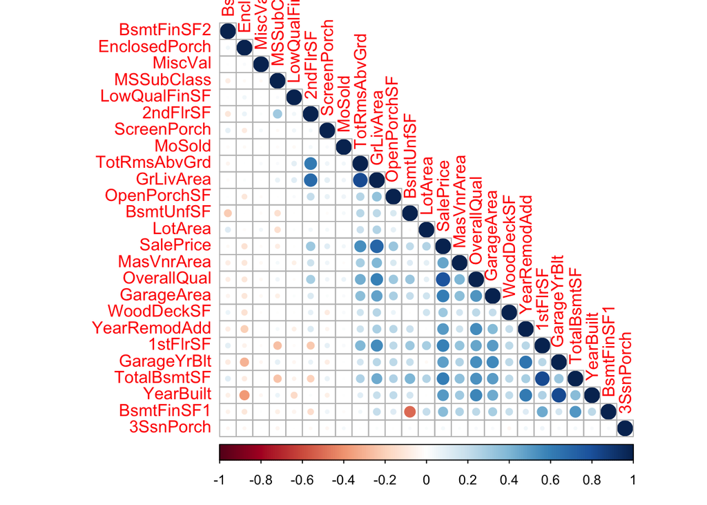

```r
ames_train_mod2 <- ames_train_mod1 %>%
  select(-one_of(vars_to_remove_sd,vars_to_remove_miss))

# Okay, the data were pretty clean already. In real applications, that would have yielded more results
# Now, check the correlation between features. This one is super important
# Note that in applications where the number of features is huge (in the thousands), you can't make a nice picture like this.
# There are two options: prescreen and drop features that have no relationship with the target (this is dangerous), or use an actual
# feature clustering algorithm
library(corrplot)
corrplot(cor(ames_train_mod2 %>% select_if(is.numeric),use="complete.obs"),type="lower",method="circle",order="AOE")
```

We see there are some clusters of highly positively correlated variables, which could adversly affect some models.

The last steps we will do is to create dummy variables for our categorical encoding, and standardize our continuous features to have mean 0 and variance 1. The former is so common that `R` has special ways of dealing with it- the `formula` interface and `model.matrix`. You may be familiar with terms of the form `y ~ x` in `R`. These are used inside modelling functions, and allow you to directly input dataframes with categorical variables into modelling functions like `lm` without manually binning.

What is actually happening is that the modelling fuction is internally calling `model.matrix`, which parses the formula and creates the appropriate $X$ matrix directly. This means that in `R`, once you have cleaned and preprocessed your data, you can just do the following:

```r
# Standardize
ames_train_std <- ames_train_mod2 %>%
  mutate_if(is.numeric,funs( (. - mean(.,na.rm=TRUE)) / sd(.,na.rm=TRUE) ))

ytrain <- ames_train_std$SalePrice

Xtrain <- model.matrix(SalePrice ~ .,data=ames_train_std)
Xtest <- model.matrix( ~ .,data=ames_test_mod1)

head(Xtrain)
```

```
##   (Intercept)  MSSubClass     LotArea OverallQual OverallCond2
## 1           1  0.07334983 -0.20707076  0.65125610            0
## 2           1 -0.87226388 -0.09185490 -0.07181151            0
## 3           1  0.07334983  0.07345481  0.65125610            0
## 4           1  0.30975326 -0.09686428  0.65125610            0
## 5           1  0.07334983  0.37501979  1.37432370            0
## 6           1 -0.16305360  0.36049258 -0.79487911            0
##   OverallCond3 OverallCond4 OverallCond5 OverallCond6 OverallCond7
## 1            0            0            1            0            0
## 2            0            0            0            0            0
## 3            0            0            1            0            0
## 4            0            0            1            0            0
## 5            0            0            1            0            0
## 6            0            0            1            0            0
##   OverallCond8 OverallCond9  YearBuilt YearRemodAdd MasVnrArea  BsmtFinSF1
```

[output cut: 76 more lines]

Note also that it added an intercept.

You’re now ready to model! There’s lots of other preprocessing you can do to structured data with interpretable features; here is a non-exhaustive list of suggestions:

- Basis function expansions, i.e. adding transformations of existing variables. You can do this right in the `model.matrix` formula
- Filter out (prescreen) non-predictive features, based on some metric with the target (e.g. correlation)
- Discretize/bin numeric variables into categorical variables- you can think of this as another type of basis function expansion, and it is very good for capturing non-linear relationships using linear models. You can pick the bin cutpoints using a decision tree (next lecture)
- You have to deal with missing values somehow, which we didn’t do here because it is too long of a discussion. Usually, people have the long discussion, and then just end up imputing with the mean anyways- but there are fancier techniques available too. Note that the `model.matrix` function silently deletes rows where any variable is missing, which is dangerous behaviour

Let’s build and partially validate a simple regression model to prove our data is usable. Note that I have to go backwards a step, since `R` does our last step internally inside `lm`.

```r
mod1 <- lm(SalePrice ~ .,data=ames_train_std)
summary(mod1)
```

```
##
## Call:
## lm(formula = SalePrice ~ ., data = ames_train_std)
##
## Residuals:
##     Min      1Q  Median      3Q     Max
## -5.0826 -0.1748 -0.0034  0.1499  2.6095
##
## Coefficients: (2 not defined because of singularities)
##                Estimate Std. Error t value Pr(>|t|)
## (Intercept)    0.239954   0.294342   0.815 0.415095
## MSSubClass    -0.062953   0.012891  -4.883 1.17e-06 ***
## LotArea        0.067118   0.011632   5.770 9.88e-09 ***
## OverallQual    0.263874   0.018889  13.970  < 2e-16 ***
## OverallCond3  -0.112875   0.232867  -0.485 0.627956
## OverallCond4   0.097970   0.221130   0.443 0.657809
## OverallCond5   0.155423   0.215791   0.720 0.471502
## OverallCond6   0.215785   0.216436   0.997 0.318953
## OverallCond7   0.295571   0.216900   1.363 0.173211
## OverallCond8   0.296965   0.220220   1.348 0.177734
## OverallCond9   0.354102   0.233677   1.515 0.129927
## YearBuilt      0.136735   0.025553   5.351 1.03e-07 ***
## YearRemodAdd   0.052976   0.016582   3.195 0.001433 **
## MasVnrArea     0.043305   0.011776   3.677 0.000245 ***
## BsmtFinSF1     0.205298   0.024966   8.223 4.74e-16 ***
## BsmtFinSF2     0.041118   0.012491   3.292 0.001022 **
## BsmtUnfSF      0.087468   0.021334   4.100 4.39e-05 ***
## TotalBsmtSF          NA         NA      NA       NA
## `1stFlrSF`     0.228519   0.025634   8.915  < 2e-16 ***
## `2ndFlrSF`     0.245478   0.025583   9.595  < 2e-16 ***
## LowQualFinSF   0.030226   0.013150   2.299 0.021687 *
## GrLivArea            NA         NA      NA       NA
## BsmtFullBath1  0.038386   0.029969   1.281 0.200474
## BsmtFullBath2 -0.036963   0.150458  -0.246 0.805976
## BsmtHalfBath1  0.028350   0.047177   0.601 0.547992
## BsmtHalfBath2 -0.335615   0.449227  -0.747 0.455141
## FullBath1     -0.171374   0.244413  -0.701 0.483324
## FullBath2     -0.170908   0.249039  -0.686 0.492666
## FullBath3      0.264349   0.264286   1.000 0.317380
## HalfBath1      0.041691   0.031462   1.325 0.185363
```

[output cut: 28 more lines]

```
## PoolArea648    0.062205   0.369115   0.169 0.866196
## PoolArea738    0.955683   0.373496   2.559 0.010617 *
## MiscVal       -0.003630   0.010074  -0.360 0.718642
## MoSold        -0.008140   0.010520  -0.774 0.439174
## YrSold2007    -0.005766   0.030244  -0.191 0.848816
## YrSold2008    -0.007771   0.031115  -0.250 0.802815
## YrSold2009    -0.007488   0.030038  -0.249 0.803192
## YrSold2010     0.002343   0.037081   0.063 0.949621
## ---
## Signif. codes:  0 '***' 0.001 '**' 0.01 '*' 0.05 '.' 0.1 ' ' 1
##
## Residual standard error: 0.3639 on 1307 degrees of freedom
##   (89 observations deleted due to missingness)
## Multiple R-squared:  0.8718, Adjusted R-squared:  0.8656
## F-statistic: 141.1 on 63 and 1307 DF,  p-value: < 2.2e-16
```

## Unstructured Data

For an example of reading in unstructured data, we will use `mnist`. Usually this comes pre-cleaned with statistical software packages, but we will read in the raw greyscale images and transform them. The resulting pipeline should work with other images as well.

We obtain the raw image data from http://yann.lecun.com/exdb/mnist/. This is in a database format; `autograd` actually also contains code for parsing it into pixel matrices. I did this behind the scenes, so what we start with here is a bunch of `.bmp` files in a folder (available, zipped, on the course website).

We need to

- Read in the training set images and store them in some type of data structure. To save time I will only read in the first 1,000 images
- Reshape the $28 \times 28$ pixel matrices into $28\times28 = 784$-dimensional vectors
- Stack these vectors in a dataframe, and
- Apply preprocessing techniques

We will use the `R` package `bmp` to start.

```r
suppressMessages({
  suppressWarnings({
    library(dplyr)
    library(bmp)
    library(purrr) # Functional programming constructs
  })
})

# Read the MNIST bitmap images into a list
# They are stored as 8-bit (0 - 255) greyscale images
# Then, reshape and stack them

mnist_dataframe <- 1:1000 %>%
  # Reads images into a list, by applying the below function to the vector 1, 2, ... , 1000
  # The result is a list of 28 x 28 pixel matrices, consisting of the numbers 0 - 255 representing intensity, where 0 is black and 255 is white
  map(~stringr::str_c("/Users/alexstringer/teaching/sta414/lectures/week9/mnist/images/train/mnist-",.x,".bmp") %>% read.bmp) %>%
  # Flatten these matrices into 784-dimensional vectors. The results will still be stored in a list
  # We do this by mapping a function over elements of the list we created in the previous step
  map(~as.numeric(.x) %>% as_data_frame() %>% t() %>% as_data_frame()) %>%
  # Stack the results in a dataframe
  # Do this by "reducing" over the list using the function bind_rows, i.e. recursively call bind_rows on elements of the list
  reduce(bind_rows)

glimpse(mnist_dataframe)
```

```
## Observations: 1,000
## Variables: 784
## $ V1   <dbl> 0, 0, 0, 0, 0, 0, 0, 0, 0, 0, 0, 0, 0, 0, 0, 0, 0, 0, 0, ...
## $ V2   <dbl> 0, 0, 0, 0, 0, 0, 0, 0, 0, 0, 0, 0, 0, 0, 0, 0, 0, 0, 0, ...
## $ V3   <dbl> 0, 0, 0, 0, 0, 0, 0, 0, 0, 0, 0, 0, 0, 0, 0, 0, 0, 0, 0, ...
## $ V4   <dbl> 0, 0, 0, 0, 0, 0, 0, 0, 0, 0, 0, 0, 0, 0, 0, 0, 0, 0, 0, ...
## $ V5   <dbl> 0, 0, 0, 0, 0, 0, 0, 0, 0, 0, 0, 0, 0, 0, 0, 0, 0, 0, 0, ...
## $ V6   <dbl> 0, 0, 0, 0, 0, 0, 0, 0, 0, 0, 0, 0, 0, 0, 0, 0, 0, 0, 0, ...
## $ V7   <dbl> 0, 0, 0, 0, 0, 0, 0, 0, 0, 0, 0, 0, 0, 0, 0, 0, 0, 0, 0, ...
## $ V8   <dbl> 0, 0, 0, 0, 0, 0, 0, 0, 0, 0, 0, 0, 0, 0, 0, 0, 0, 0, 0, ...
## $ V9   <dbl> 0, 0, 0, 0, 0, 0, 0, 0, 0, 0, 0, 0, 0, 0, 0, 0, 0, 0, 0, ...
## $ V10  <dbl> 0, 0, 0, 0, 0, 0, 0, 0, 0, 0, 0, 0, 0, 0, 0, 0, 0, 0, 0, ...
## $ V11  <dbl> 0, 0, 0, 0, 0, 0, 0, 0, 0, 0, 0, 0, 0, 0, 0, 0, 0, 0, 0, ...
## $ V12  <dbl> 0, 0, 0, 0, 0, 0, 0, 0, 0, 0, 0, 0, 0, 0, 0, 0, 0, 0, 0, ...
## $ V13  <dbl> 0, 0, 0, 0, 0, 0, 0, 0, 0, 0, 0, 0, 0, 0, 0, 0, 0, 0, 0, ...
```

[output cut: 771 more lines]

This gives us a dataframe with pixel intensities ranging from 0 to 255. We are now where we started with the structured data example- a dataframe with observations (images) in the rows, and features in the columns. There are a couple important differences:

- In the structured scenario, the features were interpretable, things like “year built” and “living space”. In any particular application, we might care specifically about the relationship between each feature and the target. We might need to go to a meeting with the business folks and answer questions like “what is the relationship between living space and house price?”.
- Contrast this to the unstructured scenario, where here our features correspond to pixels in the image. Feature $V125$ is simply the intensity of pixel # 125- do we care specifcally about this value?

We still want to scale our features, although for these data it makes more sense to scale based on the minimum and maximum value, rather than by mean and variance. Note that there is no missing data; the images in this dataset are all complete. We also will skip the step of removing features that don’t vary- this would break regression models (which need to invert a matrix), but for something like a neural network, which effectively computes derived featurs then models these, these won’t have a noticible effect.

```r
scale_variable <- function(x) {
  if (min(x) == max(x)) {
    x
  }
  else {
    (x - min(x)) / (max(x) - min(x))
  }
}

mnist_mod <- mnist_dataframe %>%
  mutate_all(scale_variable)

dim(mnist_mod)
```

```
## [1] 1000  784
```

```r
mnist_mod %>% map(~range(.x)) %>% as_data_frame() %>% t %>% as_data_frame() %>% filter(V1 != 0 | !(V2 %in% c(0,1))) # Check that all column ranges are (0,1), or (0,0)
```

```
## # A tibble: 0 x 2
## # ... with 2 variables: V1 <dbl>, V2 <dbl>
```

```r
glimpse(mnist_mod)
```

```
## Observations: 1,000
## Variables: 784
## $ V1   <dbl> 0, 0, 0, 0, 0, 0, 0, 0, 0, 0, 0, 0, 0, 0, 0, 0, 0, 0, 0, ...
## $ V2   <dbl> 0, 0, 0, 0, 0, 0, 0, 0, 0, 0, 0, 0, 0, 0, 0, 0, 0, 0, 0, ...
## $ V3   <dbl> 0, 0, 0, 0, 0, 0, 0, 0, 0, 0, 0, 0, 0, 0, 0, 0, 0, 0, 0, ...
## $ V4   <dbl> 0, 0, 0, 0, 0, 0, 0, 0, 0, 0, 0, 0, 0, 0, 0, 0, 0, 0, 0, ...
## $ V5   <dbl> 0, 0, 0, 0, 0, 0, 0, 0, 0, 0, 0, 0, 0, 0, 0, 0, 0, 0, 0, ...
## $ V6   <dbl> 0, 0, 0, 0, 0, 0, 0, 0, 0, 0, 0, 0, 0, 0, 0, 0, 0, 0, 0, ...
## $ V7   <dbl> 0, 0, 0, 0, 0, 0, 0, 0, 0, 0, 0, 0, 0, 0, 0, 0, 0, 0, 0, ...
## $ V8   <dbl> 0, 0, 0, 0, 0, 0, 0, 0, 0, 0, 0, 0, 0, 0, 0, 0, 0, 0, 0, ...
## $ V9   <dbl> 0, 0, 0, 0, 0, 0, 0, 0, 0, 0, 0, 0, 0, 0, 0, 0, 0, 0, 0, ...
## $ V10  <dbl> 0, 0, 0, 0, 0, 0, 0, 0, 0, 0, 0, 0, 0, 0, 0, 0, 0, 0, 0, ...
## $ V11  <dbl> 0, 0, 0, 0, 0, 0, 0, 0, 0, 0, 0, 0, 0, 0, 0, 0, 0, 0, 0, ...
## $ V12  <dbl> 0, 0, 0, 0, 0, 0, 0, 0, 0, 0, 0, 0, 0, 0, 0, 0, 0, 0, 0, ...
## $ V13  <dbl> 0, 0, 0, 0, 0, 0, 0, 0, 0, 0, 0, 0, 0, 0, 0, 0, 0, 0, 0, ...
```

[output cut: 771 more lines]

The data is now ready for use in models (although we didn’t read in the test set, or the image labels!)